# Lab 8.4 - Using themes

### Legend elements

The legend elements control the apperance of all legends. You can also modify the appearance of individual legends by modifying the same elements in `guide_legend()` or `guide_colourbar()`.

| Element | Setter | Description |
| --- | --- | --- |
| legend.background | `element_rect()` | legend background |
| legend.key | `element_rect()` | background of legend keys |
| legend.key.size | `unit()` | legend key size |
| legend.key.height | `unit()` | legend key height |
| legend.key.width | `unit()` | legend key width |
| legend.margin | `unit()` | legend margin |
| legend.text | `element_text()` | legend labels |
| legend.text.align | 0–1 | legend label alignment (0 = right, 1 = left) |
| legend.title | `element_text()` | legend name |
| legend.title.align | 0–1 | legend name alignment (0 = right, 1 = left) |

These options are illustrated below:

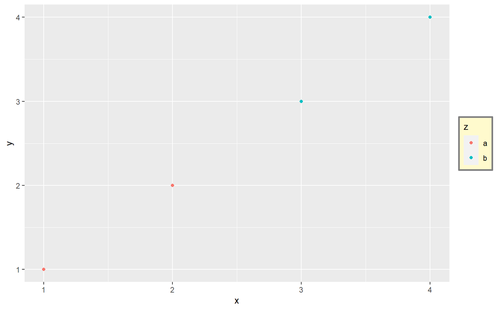

```r
df <- data.frame(x = 1:4, y = 1:4, z = rep(c("a", "b"), each = 2))
base <- ggplot(df, aes(x, y, colour = z)) + geom_point()
base + theme(legend.background = element_rect(fill = "lemonchiffon", colour = "grey50",
    size = 1))
```

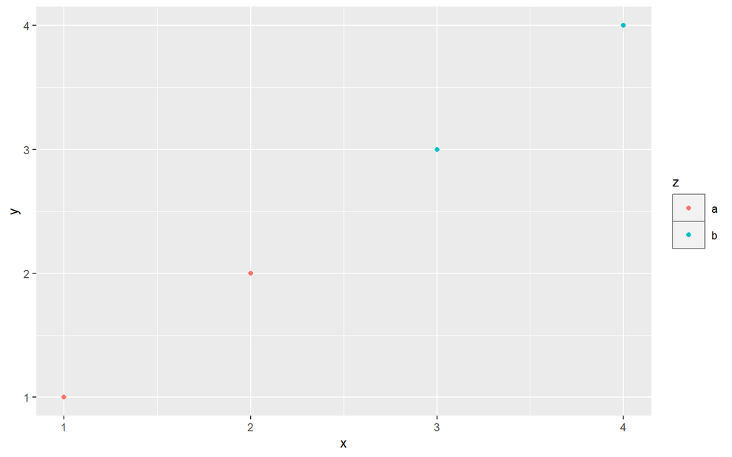

```r
base + theme(legend.key = element_rect(color = "grey50"), legend.key.width = unit(0.9,
    "cm"), legend.key.height = unit(0.75, "cm"))
```

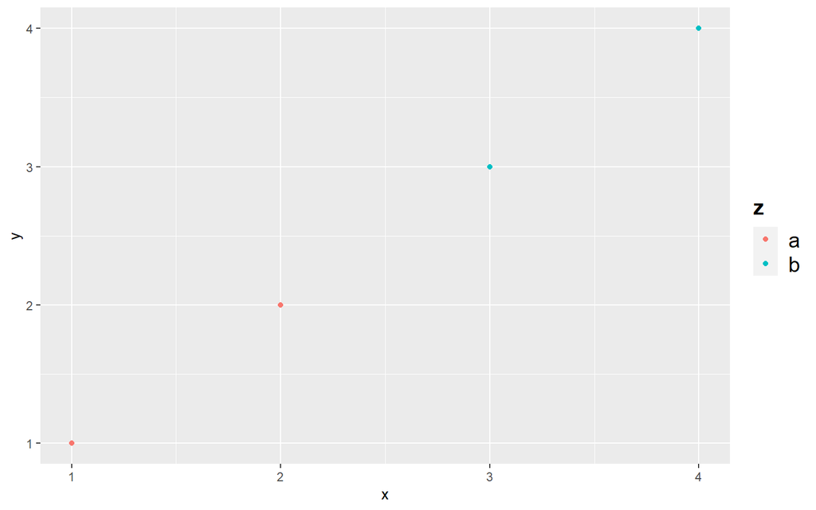

```r
base + theme(legend.text = element_text(size = 15), legend.title = element_text(size = 15,
    face = "bold"))
```

### Panel elements

Panel elements control the appearance of the plotting panels:

| Element | Setter | Description |
| --- | --- | --- |
| panel.background | `element_rect()` | panel background (under data) |
| panel.border | `element_rect()` | panel border (over data) |
| panel.grid.major | `element_line()` | major grid lines |
| panel.grid.major.x | `element_line()` | vertical major grid lines |
| panel.grid.major.y | `element_line()` | horizontal major grid lines |
| panel.grid.minor | `element_line()` | minor grid lines |
| panel.grid.minor.x | `element_line()` | vertical minor grid lines |
| panel.grid.minor.y | `element_line()` | horizontal minor grid lines |
| aspect.ratio | numeric | plot aspect ratio |

The main difference between `panel.background` and `panel.border` is that the background is drawn underneath the data, and the border is drawn on top of it. For that reason, you’ll always need to assign `fill = NA` when overriding `panel.border`.

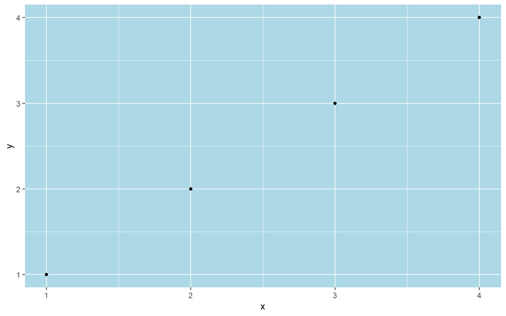

```r
base <- ggplot(df, aes(x, y)) + geom_point()
# Modify background
base + theme(panel.background = element_rect(fill = "lightblue"))
```

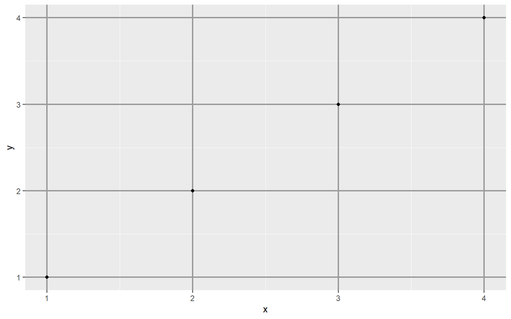

```r
# Tweak major grid lines
base + theme(panel.grid.major = element_line(color = "gray60", size = 0.8))
```

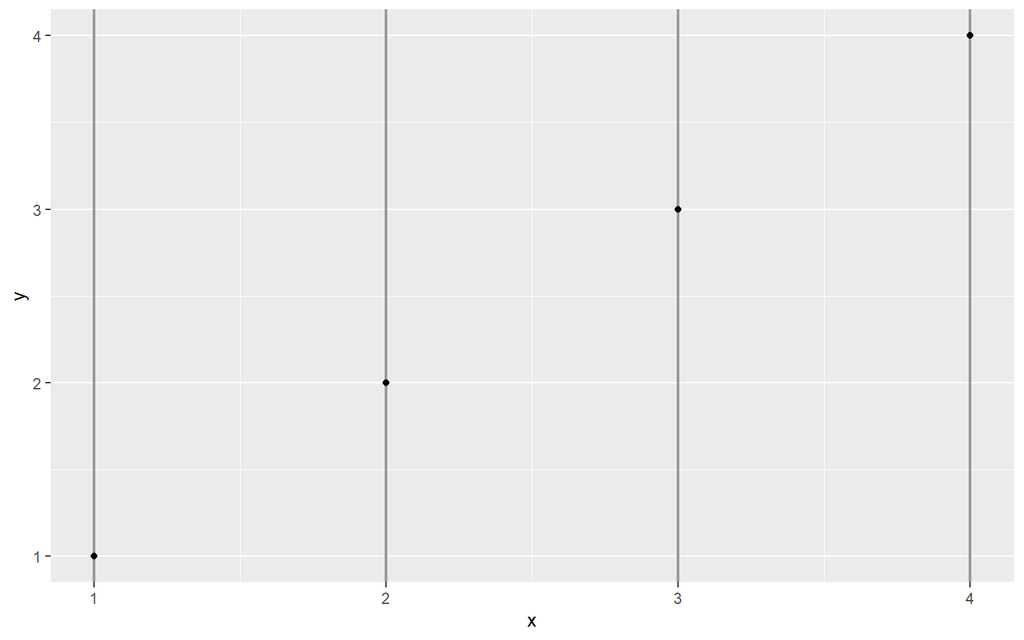

```r
# Just in one direction
base + theme(panel.grid.major.x = element_line(color = "gray60", size = 0.8))
```

Note that aspect ratio controls the aspect ratio of the *panel*, not the overall plot:

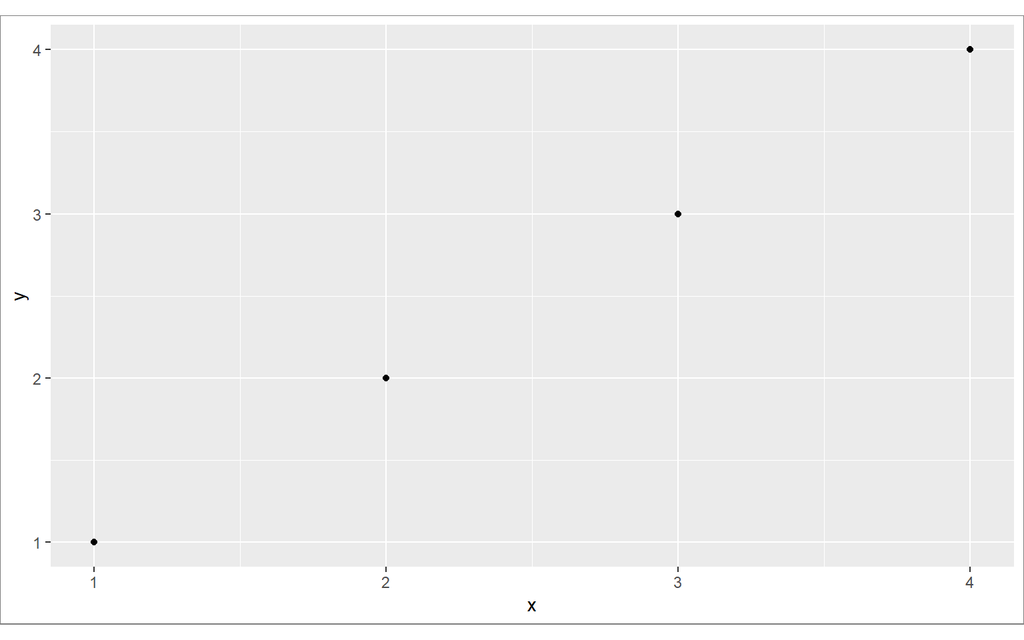

```r
base2 <- base + theme(plot.background = element_rect(colour = "grey50"))
# Wide screen
base2 + theme(aspect.ratio = 9/16)
```

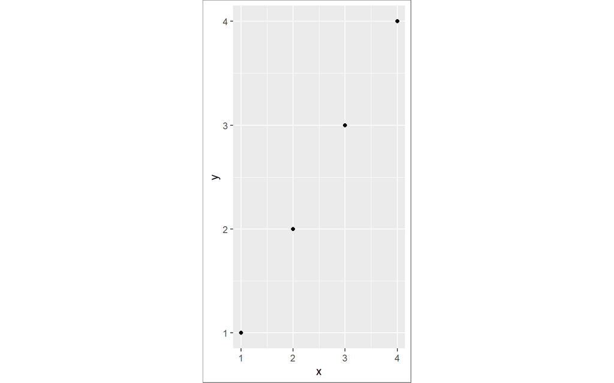

```r
# Long and skiny
base2 + theme(aspect.ratio = 2/1)
```

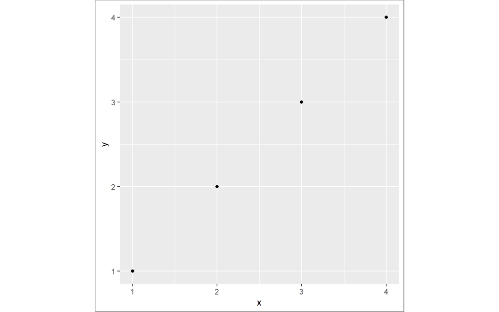

```r
# Square
base2 + theme(aspect.ratio = 1)
```